# Trabajo practico 1

Ejercicio 2

11 mayo, 2021

## Librerias y utilidades

```r
library(cluster)
library(ggrepel)
library(kableExtra)
library(tidyverse)
```

```r
source(here::here("src", "utils.R"))
```

## Datos

```r
datos <- read_csv2(here::here("data", "raw", "CUALITATIVAS.csv"))
```

```r
glimpse(datos)
```

```
## Rows: 41
## Columns: 10
## $ VARIEDAD <chr> "A1", "A2", "A3", "A4", "A5", "A6", "A7", "A8", "F1", "F2", "…
## $ TIPO     <chr> "Alf", "Alf", "Alf", "Alf", "Alf", "Alf", "Alf", "Alf", "Fra"…
## $ SEXO     <chr> "Fem", "Fem", "Fem", "Fem", "Fem", "Fem", "Fem", "Fem", "Fem"…
## $ CORNAMEN <chr> "Blanca", "Negra", "Negra", "Negra", "Negra", "Negra", "Negra…
## $ TORNAMEN <chr> "Espin", "Espin", "Pelos", "Pelos", "Espin", "Espin", "Espin"…
## $ PEDUNC   <chr> "Obt", "Obt", "Cue", "Agu", "Cue", "Cue", "Cue", "Cue", "Agu"…
## $ VERRUGAS <chr> "No", "No", "No", "No", "No", "No", "No", "No", "Si", "Si", "…
## $ MOTEADO  <chr> "No", "No", "No", "No", "No", "No", "No", "No", "No", "No", "…
## $ CLADOSP  <chr> "No", "No", "No", "-1", "No", "No", "No", "No", "Si", "No", "…
## $ CMV      <chr> "No", "No", "No", "-1", "No", "No", "No", "No", "Si", "Si", "…
```

Vemos que todas las variables fueron importadas como de tipo `"character"`, lo que es correcto en este caso, ya que todas representan variables cualitativas. Ahora pasamos a ver que variables tienen datos desconocidos (marcados con “-1”). Los reemplazaremos por valores `NA`.

```r
sapply(datos, function(x) paste(round(mean(x == "-1") * 100, 2), "%")) %>%
  t() %>%
  as.data.frame() %>%
  kable(caption = "Tabla 1: Porcentaje de datos perdidos por variable") %>%
  kable_styling(font_size = 12, full_width = FALSE) %>%
  kable_classic_2()
```

Tabla 1: Porcentaje de datos perdidos por variable

| VARIEDAD | TIPO | SEXO | CORNAMEN | TORNAMEN | PEDUNC | VERRUGAS | MOTEADO | CLADOSP | CMV |
| --- | --- | --- | --- | --- | --- | --- | --- | --- | --- |
| 0 % | 0 % | 0 % | 0 % | 0 % | 0 % | 0 % | 0 % | 31.71 % | 26.83 % |

Por lo que vemos que en las variables `CLADOSP` y `CMV` se tiene un 32% y un 27% de valores perdidos respectivamente. Procedemos a identificarlos como `NA`.

```r
datos <- datos %>%
  mutate(
    CLADOSP = ifelse(CLADOSP == "-1", NA, CLADOSP),
    CMV = ifelse(CMV == "-1", NA, CMV)
  )
```

**A.** Cuantifique (en forma manual) la similaridad entre las variedades correspondientes a la primera y segunda fila en función del porcentaje de caracteres comunes respecto al número de caracteres totales. Idem las variedades asociadas a las filas 12 y 13 (incluir la variable TIPO)

Obtenemos dos vectores que representan a cada una de las dos primeras variedades y luego calculamos el la proporcion de variables donde ambas variedades coinciden.

```r
variedad1 <- datos[1, -1] %>% unlist() %>% unname()
variedad2 <- datos[2, -1] %>% unlist() %>% unname()
similaridad_1_2 <- mean(variedad1 == variedad2, na.rm = TRUE) * 100
```

La similaridad entre las variedades de la fila 1 y 2 es del 88.89%. Luego, de manera análoga para el par de variedades 12 y 13

```r
variedad12 <- datos[12, -1] %>% unlist() %>% unname()
variedad13 <- datos[13, -1] %>% unlist() %>% unname()
similaridad_12_13 <- mean(variedad12 == variedad13, na.rm = TRUE) * 100
```

La similaridad entre las variedades de la fila 12 y 13 es del 71.43%.

**B.** Halle una matriz de similaridad entre variedades en función del coeficiente SM generalizado.

La funcion `daisy()` del paquete `cluster` requiere que las variables cualitativas sean de tipo `"factor"`. En nuestro caso, son de tipo `"character"`, por lo que necesitamos una nueva version de nuestros datos donde las columnas son factores.

```r
datos_fct <- datos %>%
  mutate_all(as.factor)
```

```r
datos_fct_df <- datos_fct[-1]
rownames(datos_fct_df) <- datos_fct$VARIEDAD
matriz_distancia <- daisy(datos_fct_df, "gower")
matriz_similaridad <- 1 - matriz_distancia
```

Comprobemos, por ejemplo, si las similaridad entre las unidades 1 y 2 computada mediante `daisy()` es igual a la que computamos a mano.

```r
matriz_similaridad[1] == (similaridad_1_2 / 100)
```

```
## [1] TRUE
```

Por lo que ambos resultados son iguales.

**C.** Aplique Análisis de Coordenadas principales para representar en un espacio bidimensional la semejanza entre las variedades.

```r
coordenadas_principales <- cmdscale(sqrt(matriz_distancia), eig = TRUE)
```

Vamos a hacer el grafico

```r
datos_CP <- as.data.frame(coordenadas_principales$points)
colnames(datos_CP) <- c("c1", "c2")
datos_CP$etiqueta <- datos$VARIEDAD
datos_CP$variedad <- substr(datos_CP$etiqueta, 1, 1)
```

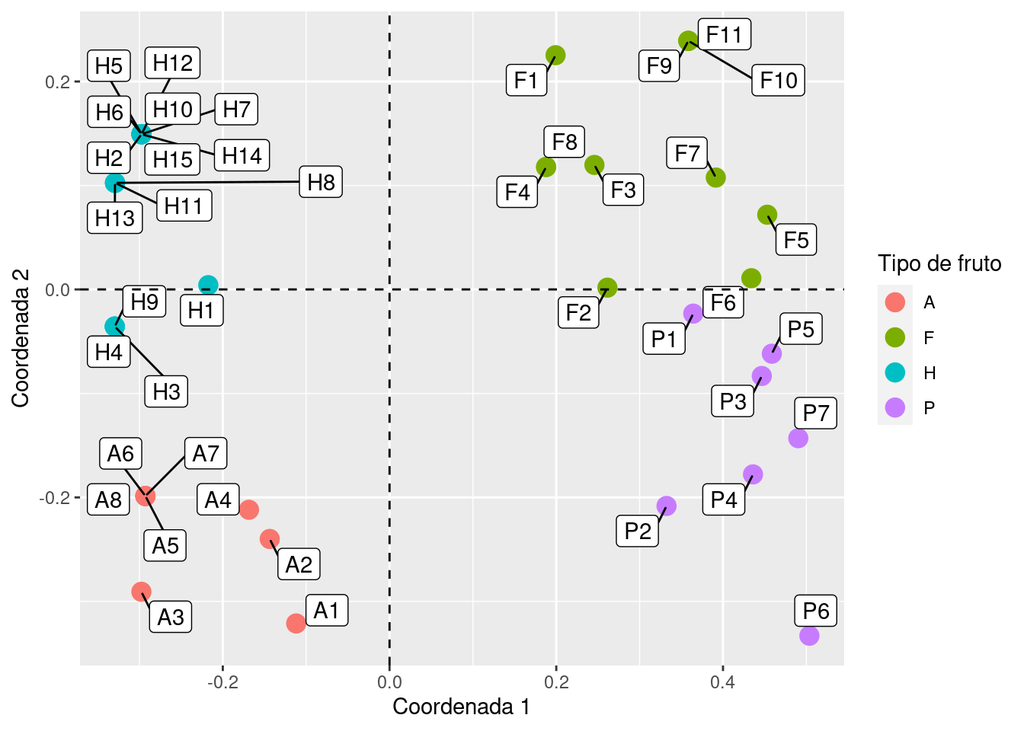

Figura 1: Caracterizacion cualitativa de las variedades de pepino.

```r
ggplot(datos_CP) +
  geom_point(aes(c1, c2, color = variedad), size = 4) +
  geom_label_repel(aes(c1, c2, label = etiqueta), max.overlaps = 30) +
  geom_vline(xintercept = 0, linetype = "dashed") +
  geom_hline(yintercept = 0, linetype = "dashed") +
  labs(
    x = "Coordenada 1",
    y = "Coordenada 2",
    color = "Tipo de fruto"
  )
```

En aquellos casos que mas de una etiqueta apunta hacia el mismo punto sucede que las variedades coinciden en terminos de las variables analizadas y en consecuencia los puntos que los representan estan encimados. Por ejemplo, las variedades `A5`, `A6`, `A7`, `A8` tienen idénticos valores para todas las variables.

```r
datos %>%
  filter(VARIEDAD %in% c("A5", "A6", "A7", "A8")) %>%
  kable() %>%
  kable_styling(font_size = 12, full_width = FALSE) %>%
  kable_classic_2()
```

| VARIEDAD | TIPO | SEXO | CORNAMEN | TORNAMEN | PEDUNC | VERRUGAS | MOTEADO | CLADOSP | CMV |
| --- | --- | --- | --- | --- | --- | --- | --- | --- | --- |
| A5 | Alf | Fem | Negra | Espin | Cue | No | No | No | No |
| A6 | Alf | Fem | Negra | Espin | Cue | No | No | No | No |
| A7 | Alf | Fem | Negra | Espin | Cue | No | No | No | No |
| A8 | Alf | Fem | Negra | Espin | Cue | No | No | No | No |

**D.** Conforme grupos de variedades según su homogeneidad en la caracterización agronómica cualitativa.

En la Figura 1 se puede ver que las variedades de los tipos de fruto A y H se se agrupan de manera que respetan al tipo de fruto y se diferencian del resto. Tambien existe una agrupacion, ya no tan clara, para las variedades de los grupos F y P. En este caso, si no estuviera el color que diferencie a los tipos de frutos, no podriamos diferenciar a estos dos grupos claramente. Por ejemplo, las variedades F2, F6 y P1 estan muy cercanas en el plano y las podriamos haber tomado como parte de un mismo grupo.

**E.** Encuentre el dendograma ultramétrico con ligamiento UPGMA correspondiente

En el dendograma se muestran coloreados los 4 clusters obtenidos.

```r
cluster_cualitativas <- hclust(matriz_distancia, method = "average")
```

```r
# funcion creada en src/utils.R
dendro_data <- dendro_data_k(cluster_cualitativas, k=4)
```

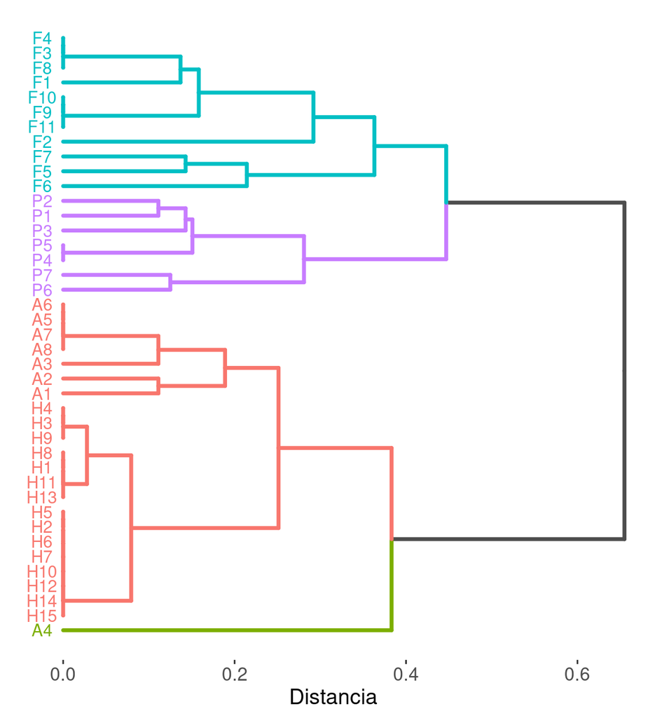

Figura 2: Dendograma Ultrametrico con ligamiento UPGMA.

```r
ggplot(dendro_data$segments) +
  geom_segment(
    aes(x = x, y = y, xend = xend, yend = yend, color = as.factor(clust)),
    size = 1.2,
    lineend = "round"
  ) +
  geom_text(
    aes(x = x, y = y - 0.025, label = label, color = as.factor(clust)),
    data = dendro_data$labels
  ) +
  coord_flip() +
  labs(
    y = "Distancia"
  ) +
  scale_colour_manual(
    values = c("grey30", scales::hue_pal()(4))
  ) +
  theme(
    panel.grid.major = element_blank(),
    panel.grid.minor = element_blank(),
    panel.background = element_blank(),
    axis.title.x = element_text(size = 14),
    axis.title.y = element_blank(),
    axis.text.x = element_text(size = 12),
    axis.text.y = element_blank(),
    axis.line = element_blank(),
    axis.ticks.y = element_blank(),
    plot.title = element_text(hjust = 0.5),
    legend.position = "none"
  )
```

**F.** Mida a través de su matriz cofenética la concordancia con la matriz de distancias que le dio origen

Primero vamos a calcular la concordancia y luego obtenemos un grafico de dispersion donde se muestra la distancia original y la distancia cofenética.

```r
distancia_cofenetica <- cophenetic(cluster_cualitativas)
concordancia <- cor(distancia_cofenetica, matriz_distancia)
```

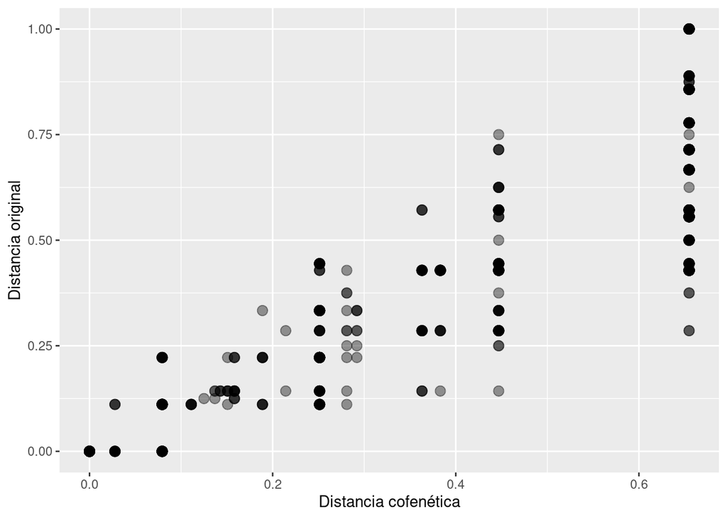

Figura 3: Grafico de dispersion entre distancia original y distancia cofenética.

```r
concordancia_df <- data.frame(
    x = as.vector(distancia_cofenetica),
    y = as.vector(matriz_distancia)
)
ggplot(concordancia_df) +
    geom_point(aes(x, y), size = 3, alpha = 0.4) +
    labs(
        x = "Distancia cofenética",
        y = "Distancia original"
    )
```

La concordancia entre la matriz de distancias cofenética y la matriz de distancia original es igual a 0.883.

**G.** Cuantifique concordancia entre plano principal de ACoordP y Cluster

```r
concordancia <- cor(distancia_cofenetica, dist(coordenadas_principales$points))
```

La concordancia concordancia entre plano principal de ACoordP y Cluster es 0.891.